# AdverseDrugReactions

Thirupathi Pattipaka

7/5/2017

## Introduction

The U.S. Food and Drug Administration (FDA) regulates over-the- counter and prescription drugs in the United States, including biological therapeutics and generic drugs. This work covers more than just medicines. For example, fluoride toothpaste, antiperspirants, dandruff shampoos and sunscreens are all considered drugs.

An adverse event is submitted to the FDA to report any undesirable experience associated with the use of a medical product in a patient. For drugs, this includes serious drug side effects, product use errors, product quality problems, and therapeutic failures for prescription or over-the- counter medicines and medicines administered to hospital patients or at outpatient infusion centers.

The FDA’s database of adverse event reports is made available through a web API at https://open.fda.gov/drug/event/. Each report contains general information about the report, patient information, a list of the drugs that the patient is taking, and a list of the patient reactions. It is possible to use these data in many ways: your brief is to explore these data and to see what might be learned from them.

The analysis is aimed to understand whether different adverse events reported in different countries?

## Loading list of libraries

## Downloading data from openfda website(JSON files)

I am downloading drug adverse event data https://open.fda.gov/drug/event/reference/. The openFDA drug adverse event API returns data from the FDA Adverse Event Reporting System (FAERS), a database that contains information on adverse event and medication error reports submitted to FDA.

```r
for (i in 80:87) {
  if (i<10){
    url = paste0("https://download.open.fda.gov/drug/event/all_other/drug-event-000",i,"-of-0087.json.zip")
  }
  else{
    url = paste0("https://download.open.fda.gov/drug/event/all_other/drug-event-00",i,"-of-0087.json.zip")
  }
  download(url,dest="json.zip")
  unzip ("json.zip")
  }
```

To check whether all files are downloaded

```r
dir()
```

```
##  [1] "drug-event-0080-of-0087.json" "drug-event-0081-of-0087.json"
##  [3] "drug-event-0082-of-0087.json" "drug-event-0083-of-0087.json"
##  [5] "drug-event-0084-of-0087.json" "drug-event-0085-of-0087.json"
##  [7] "drug-event-0086-of-0087.json" "drug-event-0087-of-0087.json"
##  [9] "Index.html"                   "Index.Rmd"
## [11] "json.zip"                     "README.md"
## [13] "test.R"
```

To create a character vector of the all json files

```r
filenames <- list.files(pattern="*.json", full.names=TRUE)
filenames
```

```
## [1] "./drug-event-0080-of-0087.json" "./drug-event-0081-of-0087.json"
## [3] "./drug-event-0082-of-0087.json" "./drug-event-0083-of-0087.json"
## [5] "./drug-event-0084-of-0087.json" "./drug-event-0085-of-0087.json"
## [7] "./drug-event-0086-of-0087.json" "./drug-event-0087-of-0087.json"
```

## Understanding the data

To read JSON data, I am using the fromJSON function from the jsonlite package. Let’s read in one of the data files and print the content.

```r
drug1 = fromJSON(filenames[1])
```

```r
names(drug1)
```

```
## [1] "meta"    "results"
```

what meta contains

```r
drug1$meta
```

```
## $last_updated
## [1] "2017-07-01"
##
## $terms
## [1] "https://open.fda.gov/terms/"
##
## $results
## $results$skip
## [1] 1185000
##
## $results$total
## [1] 1291065
##
## $results$limit
## [1] 15000
##
##
## $license
## [1] "https://open.fda.gov/license/"
##
## $disclaimer
## [1] "Do not rely on openFDA to make decisions regarding medical care. While we make every effort to ensure that data is accurate, you should assume all results are unvalidated. We may limit or otherwise restrict your access to the API in line with our Terms of Service."
```

what results contains

```r
results=drug1$results
class(results)
```

```
## [1] "data.frame"
```

```r
glimpse(results)
```

```
## Observations: 15,000
## Variables: 27
## $ receivedate                  <chr> "20131224", "20131225", "20131227...
## $ receivedateformat            <chr> "102", "102", "102", "102", "102"...
## $ patient                      <data.frame> c("Pneumonia, 19.1, 5", "D...
## $ sender                       <data.frame> c("FDA-Public Use", "FDA-P...
## $ transmissiondate             <chr> "20161109", "20161109", "20161109...
## $ companynumb                  <chr> "GB-ROCHE-1324516", "GB-ROCHE-132...
## $ occurcountry                 <chr> "GB", "GB", "US", "US", "US", "US...
## $ receiptdate                  <chr> "20160831", "20160830", "20160729...
## $ transmissiondateformat       <chr> "102", "102", "102", "102", "102"...
## $ receiptdateformat            <chr> "102", "102", "102", "102", "102"...
## $ primarysource                <data.frame> c("GB", "GB", "US", "US", ...
## $ duplicate                    <chr> "1", "1", "1", "1", "1", "1", "1"...
## $ seriousnessdeath             <chr> "1", "1", NA, NA, "1", NA, NA, NA...
## $ reporttype                   <chr> "2", "2", "1", "1", "2", "1", "1"...
## $ reportduplicate              <data.frame> c("GB-ROCHE-1324516", "GB-...
## $ receiver                     <data.frame> c("FDA", "FDA", "FDA", "FD...
## $ serious                      <chr> "1", "1", "1", "2", "1", "1", "2"...
## $ safetyreportversion          <chr> "2", "2", "5", "2", "2", "2", "6"...
## $ fulfillexpeditecriteria      <chr> "1", "1", "1", "2", "1", "1", "2"...
## $ safetyreportid               <chr> "9781738", "9781860", "9786252", ...
## $ primarysourcecountry         <chr> "GB", "GB", "US", "US", "US", "US...
## $ seriousnessother             <chr> NA, "1", "1", NA, NA, "1", NA, "1...
## $ seriousnesshospitalization   <chr> NA, NA, NA, NA, NA, NA, NA, NA, "...
## $ authoritynumb                <chr> NA, NA, NA, NA, NA, NA, NA, NA, N...
## $ seriousnessdisabling         <chr> NA, NA, NA, NA, NA, NA, NA, NA, N...
## $ seriousnesslifethreatening   <chr> NA, NA, NA, NA, NA, NA, NA, NA, N...
## $ seriousnesscongenitalanomali <chr> NA, NA, NA, NA, NA, NA, NA, NA, N...
```

As we can above, results contains 27 variables, out of those patients, sender,primarysource,reportduplicate and receiver are dataframes and others are character variables

```r
glimpse(results$patient)
```

```
## Observations: 15,000
## Variables: 8
## $ reaction            <list> [<Pneumonia, 19.1, 5>, <c("Disease progre...
## $ patientonsetage     <chr> "47", "75", NA, NA, NA, NA, "54", "69", NA...
## $ drug                <list> [<c("CAPECITABINE.", "MORPHINE SULFATE.",...
## $ summary             <data.frame> c("CASE EVENT DATE: 20090917", "CAS...
## $ patientsex          <chr> "1", "2", "2", "2", "2", NA, "2", "2", "1"...
## $ patientonsetageunit <chr> "801", "801", "801", "801", "801", NA, "80...
## $ patientweight       <chr> NA, NA, "61", NA, NA, NA, NA, NA, NA, NA, ...
## $ patientagegroup     <chr> NA, NA, NA, NA, NA, NA, NA, NA, NA, NA, NA...
```

To explore further about reaction list

```
## List of 1
##  $ :'data.frame':    1 obs. of  3 variables:
##   ..$ reactionmeddrapt       : chr "Pneumonia"
##   ..$ reactionmeddraversionpt: chr "19.1"
##   ..$ reactionoutcome        : chr "5"
```

The reaction contains 15000 lists, each patient with one list. Each list contains reactionmeddrapt variable which is included with the list of adverse reactions

Understand drug list in patient

```r
glimpse(results$patient$drug[1])
```

```
## List of 1
##  $ :'data.frame':    7 obs. of  12 variables:
##   ..$ medicinalproduct            : chr [1:7] "CAPECITABINE." "MORPHINE SULFATE." "DICLOFENAC" "SARGRAMOSTIM" ...
##   ..$ drugindication              : chr [1:7] "PANCREATIC CARCINOMA" NA NA "PANCREATIC CARCINOMA" ...
##   ..$ drugcharacterization        : chr [1:7] "1" "2" "2" "1" ...
##   ..$ drugadministrationroute     : chr [1:7] "048" NA NA "023" ...
##   ..$ drugseparatedosagenumb      : chr [1:7] "2" NA NA NA ...
##   ..$ drugdosagetext              : chr [1:7] "ON DAYS 1-21" NA NA NA ...
##   ..$ openfda                     :'data.frame': 7 obs. of  18 variables:
##   .. ..$ manufacturer_name :List of 7
##   .. ..$ unii              :List of 7
##   .. ..$ product_type      :List of 7
##   .. ..$ rxcui             :List of 7
##   .. ..$ spl_set_id        :List of 7
##   .. ..$ route             :List of 7
##   .. ..$ generic_name      :List of 7
##   .. ..$ brand_name        :List of 7
##   .. ..$ product_ndc       :List of 7
##   .. ..$ pharm_class_epc   :List of 7
##   .. ..$ substance_name    :List of 7
##   .. ..$ spl_id            :List of 7
##   .. ..$ pharm_class_moa   :List of 7
##   .. ..$ application_number:List of 7
##   .. ..$ nui               :List of 7
##   .. ..$ package_ndc       :List of 7
##   .. ..$ pharm_class_cs    :List of 7
##   .. ..$ pharm_class_pe    :List of 7
##   ..$ drugintervaldosageunitnumb  : chr [1:7] "1" NA NA NA ...
##   ..$ activesubstance             :'data.frame': 7 obs. of  1 variable:
##   .. ..$ activesubstancename: chr [1:7] "CAPECITABINE" "MORPHINE SULFATE" "DICLOFENAC" "SARGRAMOSTIM" ...
##   ..$ drugintervaldosagedefinition: chr [1:7] "804" NA NA NA ...
##   ..$ drugauthorizationnumb       : chr [1:7] "020896" NA NA NA ...
##   ..$ drugdosageform              : chr [1:7] "TABLET" NA NA NA ...
```

The list drug contains variables like medicinalproduct, drugindication and other dataframe openfda which contains variables like manufacturer_name,generic_name,brand_name etc.,

To understand primary source

```r
glimpse(results$primarysource)
```

```
## Observations: 15,000
## Variables: 3
## $ reportercountry     <chr> "GB", "GB", "US", "US", "US", "US", "US", ...
## $ qualification       <chr> "1", "1", "5", "5", "5", "4", "1", "5", "5...
## $ literaturereference <chr> NA, NA, NA, NA, NA, NA, NA, NA, NA, NA, NA...
```

All three variables in the primary source are character variables

```r
glimpse(results$reportduplicate)
```

```
## Observations: 15,000
## Variables: 2
## $ duplicatenumb   <chr> "GB-ROCHE-1324516", "GB-ROCHE-1325045", "US-FR...
## $ duplicatesource <chr> "ROCHE", "ROCHE", "FOREST", "BOEHRINGER INGELH...
```

All two columns in the reportduplicate are character variables

```r
glimpse(results$receiver)
```

```
## Observations: 15,000
## Variables: 2
## $ receiverorganization <chr> "FDA", "FDA", "FDA", "FDA", "FDA", "FDA",...
## $ receivertype         <chr> "6", "6", "6", "6", "6", "6", "6", "6", "...
```

All two columns in the receiver are also character variables

## Merging the data

Now, let’s select certain variables from each data file and merge them and see adverse events reported in different countries As a starting point, I will select drugname, drugindication, occurcountry, Adverse event, reportercountry, primarysourcecountry, etc.,

```r
#drugname
drugname <-  NULL

for (i in 1:15000) {
  drugname <- rbind(drugname, results$patient$drug[[i]][["medicinalproduct"]] %>% paste( collapse=","))
}


#drugindication
drugindication <- NULL

for (i in 1:15000) {
  drugindication <- rbind(drugindication, results$patient$drug[[i]][["drugindication"]] %>% paste( collapse=","))
}

AE <- NULL
for (i in 1:15000) {
  AE <- rbind (AE, results$patient$reaction[[i]][["reactionmeddrapt"]] %>%  unlist() %>% paste(collapse=","))
  }

df <-  cbind(results[,!(names(results) %in% c("patient","sender","receiver","primarysource","reportduplicate"))],
             results$patient[,!(names(results$patient) %in% c("reaction","drug","patientdeath","summary"))],
             results$primarysource,
             drugname = drugname,
             drugindication= drugindication,
             AE = AE)
```

Merging all files

```r
for(j in 2:8){                      # read all the rest

      tmp =fromJSON(filenames[j])$results
      #drugname
      drugname <-  NULL

      for (i in 1:nrow(tmp)) {
          drugname <- rbind(drugname, tmp$patient$drug[[i]][["medicinalproduct"]] %>% paste( collapse=","))
      }

      #drugindication
      drugindication <- NULL

      for (i in 1:nrow(tmp)) {
          drugindication <- rbind(drugindication, tmp$patient$drug[[i]][["drugindication"]] %>% paste( collapse=","))
      }

      AE <- NULL
      for (i in 1:nrow(tmp)) {
          AE <- rbind (AE, tmp$patient$reaction[[i]][["reactionmeddrapt"]] %>%  unlist() %>% paste(collapse=","))
       }
      #df.new <-  cbind(tmp,tmp$patient,tmp$primarysource,drugname = drugname,drugindication= drugindication)
      df_new <-  cbind(tmp[,!(names(tmp) %in% c("patient","sender","receiver","primarysource","reportduplicate"))],
                       tmp$patient[,!(names(tmp$patient) %in% c("reaction","drug","patientdeath","summary"))],
                       tmp$primarysource,
                       drugname = drugname,
                       drugindication= drugindication,
                       AE = AE)

   df=smartbind(df, df_new)  # concatenate all
}
```

Final dataset for further processing

```r
glimpse(df)
```

```
## Observations: 106,065
## Variables: 33
## $ receivedate                  <chr> "20131224", "20131225", "20131227...
## $ receivedateformat            <chr> "102", "102", "102", "102", "102"...
## $ transmissiondate             <chr> "20161109", "20161109", "20161109...
## $ companynumb                  <chr> "GB-ROCHE-1324516", "GB-ROCHE-132...
## $ occurcountry                 <chr> "GB", "GB", "US", "US", "US", "US...
## $ receiptdate                  <chr> "20160831", "20160830", "20160729...
## $ transmissiondateformat       <chr> "102", "102", "102", "102", "102"...
## $ receiptdateformat            <chr> "102", "102", "102", "102", "102"...
## $ duplicate                    <chr> "1", "1", "1", "1", "1", "1", "1"...
## $ seriousnessdeath             <chr> "1", "1", NA, NA, "1", NA, NA, NA...
## $ reporttype                   <chr> "2", "2", "1", "1", "2", "1", "1"...
## $ serious                      <chr> "1", "1", "1", "2", "1", "1", "2"...
## $ safetyreportversion          <chr> "2", "2", "5", "2", "2", "2", "6"...
```

[output cut: 20 more lines]

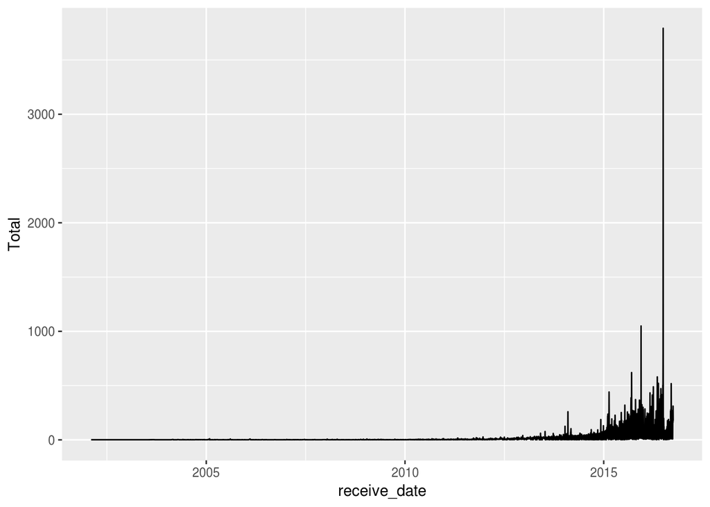

```r
df = mutate(df,receive_date =ymd(receivedate))
df%>% group_by(receive_date) %>% summarize(Total=n()) %>% ggplot(aes(x=receive_date,y=Total)) + geom_line()
```

```r
#categorization of source country
df_ <- df %>%  select(safetyreportid, occurcountry,reportercountry, AE,drugname,patientonsetage,serious,primarysourcecountry,drugindication)
df_$occurcountry <- ifelse(is.na(df_$occurcountry),df_$primarysourcecountry,df_$occurcountry)
df_ <- df_ %>% mutate(occurcountry_g = case_when(.$occurcountry=='US'~"United states",
                                               .$occurcountry=='JP'~"Japan",
                                               .$occurcountry=='GB'~"Great Britain",
                                               .$occurcountry=='FR'~"France",
                                               .$occurcountry =='CA'~"Canada",
                                               .$occurcountry =='DE'~"Germany"
                                                ))
df_$occurcountry_g <- ifelse(is.na(df_$occurcountry_g),"Other",df_$occurcountry_g)

df2 <- df_ %>%
       mutate(AE2 = strsplit(as.character(AE), ",")) %>%
       unnest(AE2)
```

## Adverse events by country

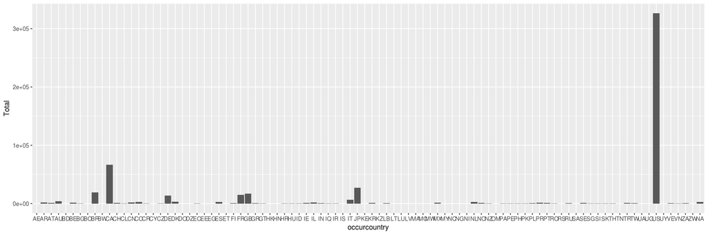

```r
df2%>% group_by(occurcountry) %>%summarize(Total=n()) %>% filter(Total >10) %>% ggplot(aes(x=occurcountry,y=Total))+ geom_bar(stat="identity")
```

```r
df2%>% group_by(occurcountry) %>% summarize(Total=n()) %>% mutate(Proportion = 100*Total / sum(Total)) %>% filter(Total >10) %>%  ungroup() %>%
    arrange(desc(Total)) %>% kable(digits=2)
```

| occurcountry | Total | Proportion |
| --- | --- | --- |
| US | 326680 | 60.21 |
| CA | 66544 | 12.27 |
| JP | 27192 | 5.01 |
| BR | 19180 | 3.54 |
| GB | 16882 | 3.11 |
| FR | 14984 | 2.76 |
| DE | 13812 | 2.55 |
| IT | 6431 | 1.19 |
| AU | 4049 | 0.75 |
| DK | 3148 | 0.58 |
| CO | 2947 | 0.54 |
| ES | 2741 | 0.51 |
| NL | 2679 | 0.49 |
| NA | 2673 | 0.49 |
| AR | 2000 | 0.37 |
| CN | 1811 | 0.33 |
| IL | 1771 | 0.33 |
| MX | 1686 | 0.31 |
| PR | 1649 | 0.30 |
| BE | 1426 | 0.26 |
| AT | 1321 | 0.24 |
| KR | 1269 | 0.23 |
| CH | 1254 | 0.23 |
| SE | 1242 | 0.23 |
| TR | 1232 | 0.23 |
| PT | 1117 | 0.21 |
| NO | 1081 | 0.20 |
| IE | 1018 | 0.19 |
| TW | 926 | 0.17 |
| PL | 871 | 0.16 |

[output cut: 62 more lines]

Countries with more than two adverse events reported in each report

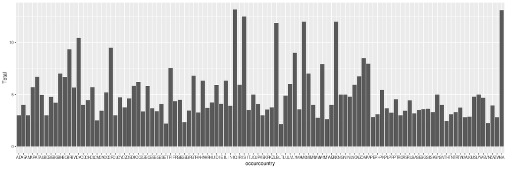

```r
df2%>% group_by(occurcountry) %>% summarize(Total=n()/n_distinct(safetyreportid)) %>% filter(Total >2) %>% ggplot(aes(x=occurcountry,y=Total))+ geom_bar(stat="identity")
```

## Top 100 Adverse drug reactions

```r
df2 %>% group_by(AE2) %>% summarize(Total=n()) %>% mutate(Proportion = 100*Total / sum(Total))  %>%  ungroup() %>%
    arrange(desc(Total)) %>% head(100) %>% kable(digits=2)
```

| AE2 | Total | Proportion |
| --- | --- | --- |
| Drug ineffective | 7659 | 1.41 |
| Fatigue | 7536 | 1.39 |
| Nausea | 6210 | 1.14 |
| Pain | 5946 | 1.10 |
| Diarrhoea | 5872 | 1.08 |
| Off label use | 5737 | 1.06 |
| Headache | 5405 | 1.00 |
| Dyspnoea | 5109 | 0.94 |
| Malaise | 5076 | 0.94 |
| Product use issue | 4235 | 0.78 |
| Dizziness | 4231 | 0.78 |
| Fall | 4126 | 0.76 |
| Arthralgia | 4015 | 0.74 |
| Asthenia | 3858 | 0.71 |
| Vomiting | 3803 | 0.70 |
| Pain in extremity | 3725 | 0.69 |
| Death | 3625 | 0.67 |
| Pneumonia | 3586 | 0.66 |
| Gastrointestinal haemorrhage | 3467 | 0.64 |
| Weight decreased | 3430 | 0.63 |
| Pyrexia | 3401 | 0.63 |
| Drug dose omission | 2980 | 0.55 |
| Cough | 2952 | 0.54 |
| Anxiety | 2899 | 0.53 |
| Gynaecomastia | 2807 | 0.52 |
| Rash | 2659 | 0.49 |
| Anaemia | 2653 | 0.49 |
| Insomnia | 2607 | 0.48 |
| Depression | 2577 | 0.47 |
| Back pain | 2564 | 0.47 |

[output cut: 70 more lines]

Adverse events by country

```r
df2 %>%
  group_by(AE2,occurcountry_g) %>%
  summarise(Total = n()) %>%
  mutate(Total_events= sum(Total)) %>% spread(occurcountry_g, Total) %>% arrange(-Total_events) %>% head(100) %>%
  kable(col.names=c("Adverse event","Total number of events","Canada","France","Germany","Great Britain","Japan","Other","USA"))
```

| Adverse event | Total number of events | Canada | France | Germany | Great Britain | Japan | Other | USA |
| --- | --- | --- | --- | --- | --- | --- | --- | --- |
| Drug ineffective | 7659 | 1043 | 76 | 64 | 79 | 118 | 718 | 5561 |
| Fatigue | 7536 | 1213 | 91 | 150 | 211 | 66 | 789 | 5016 |
| Nausea | 6210 | 821 | 63 | 160 | 154 | 263 | 602 | 4147 |
| Pain | 5946 | 892 | 37 | 52 | 74 | 38 | 826 | 4027 |
| Diarrhoea | 5872 | 745 | 116 | 146 | 175 | 309 | 727 | 3654 |
| Off label use | 5737 | 258 | 235 | 121 | 113 | 235 | 674 | 4101 |
| Headache | 5405 | 750 | 88 | 82 | 140 | 132 | 643 | 3570 |
| Dyspnoea | 5109 | 752 | 94 | 158 | 172 | 95 | 630 | 3208 |
| Malaise | 5076 | 887 | 61 | 24 | 204 | 238 | 727 | 2935 |
| Product use issue | 4235 | 220 | 66 | 27 | 39 | 51 | 360 | 3472 |
| Dizziness | 4231 | 530 | 36 | 94 | 115 | 72 | 530 | 2854 |
| Fall | 4126 | 565 | 73 | 94 | 135 | 99 | 470 | 2690 |
| Arthralgia | 4015 | 830 | 52 | 90 | 126 | 76 | 635 | 2206 |
| Asthenia | 3858 | 523 | 119 | 71 | 93 | 31 | 677 | 2344 |
| Vomiting | 3803 | 460 | 91 | 119 | 152 | 198 | 625 | 2158 |
| Pain in extremity | 3725 | 536 | 33 | 38 | 90 | 46 | 588 | 2394 |
| Death | 3625 | 206 | 48 | 65 | 278 | 89 | 421 | 2518 |
| Pneumonia | 3586 | 606 | 64 | 136 | 114 | 336 | 638 | 1692 |
| Gastrointestinal haemorrhage | 3467 | 27 | 22 | 22 | 12 | 54 | 76 | 3254 |
| Weight decreased | 3430 | 742 | 63 | 83 | 47 | 44 | 536 | 1915 |
| Pyrexia | 3401 | 449 | 142 | 124 | 96 | 532 | 824 | 1234 |
| Drug dose omission | 2980 | 93 | 8 | 5 | 45 | 5 | 114 | 2710 |
| Cough | 2952 | 713 | 49 | 54 | 70 | 62 | 339 | 1665 |
| Anxiety | 2899 | 256 | 47 | 6 | 82 | 13 | 240 | 2255 |
| Gynaecomastia | 2807 | 4 | 3 | NA | 4 | 2 | 13 | 2781 |
| Rash | 2659 | 355 | 42 | 52 | 58 | 236 | 273 | 1643 |
| Anaemia | 2653 | 123 | 128 | 101 | 95 | 466 | 543 | 1197 |
| Insomnia | 2607 | 296 | 28 | 20 | 103 | 73 | 259 | 1828 |
| Depression | 2577 | 181 | 40 | 42 | 81 | 29 | 255 | 1949 |
| Back pain | 2564 | 398 | 27 | 39 | 52 | 42 | 292 | 1714 |

[output cut: 70 more lines]

BY occur country groups

```r
df2%>% group_by(occurcountry_g) %>%summarize(Total=n()) %>%  mutate(Percentage=100*Total/sum(Total)) %>% kable(col.names=c("Country name","Total number of safety reports","Percentage"),digits=1)
```

| Country name | Total number of safety reports | Percentage |
| --- | --- | --- |
| Canada | 66544 | 12.3 |
| France | 14984 | 2.8 |
| Germany | 13812 | 2.5 |
| Great Britain | 16882 | 3.1 |
| Japan | 27192 | 5.0 |
| Other | 76444 | 14.1 |
| United states | 326680 | 60.2 |

Percentage of events in each country

```r
df2 %>%
  group_by(AE2,occurcountry_g) %>%
  summarise(Total = n()) %>% mutate(freq=100*Total/sum(Total)) %>%
  mutate(Total_events= sum(Total)) %>% select(AE2,occurcountry_g,Total_events,freq) %>% spread(occurcountry_g, freq) %>% arrange(-Total_events) %>% head(100) %>%
  kable(col.names=c("Adverse event","Total number of events","Canada","France","Germany","Great Britain","Japan","Other","USA"),digits=1)
```

| Adverse event | Total number of events | Canada | France | Germany | Great Britain | Japan | Other | USA |
| --- | --- | --- | --- | --- | --- | --- | --- | --- |
| Drug ineffective | 7659 | 13.6 | 1.0 | 0.8 | 1.0 | 1.5 | 9.4 | 72.6 |
| Fatigue | 7536 | 16.1 | 1.2 | 2.0 | 2.8 | 0.9 | 10.5 | 66.6 |
| Nausea | 6210 | 13.2 | 1.0 | 2.6 | 2.5 | 4.2 | 9.7 | 66.8 |
| Pain | 5946 | 15.0 | 0.6 | 0.9 | 1.2 | 0.6 | 13.9 | 67.7 |
| Diarrhoea | 5872 | 12.7 | 2.0 | 2.5 | 3.0 | 5.3 | 12.4 | 62.2 |
| Off label use | 5737 | 4.5 | 4.1 | 2.1 | 2.0 | 4.1 | 11.7 | 71.5 |
| Headache | 5405 | 13.9 | 1.6 | 1.5 | 2.6 | 2.4 | 11.9 | 66.0 |
| Dyspnoea | 5109 | 14.7 | 1.8 | 3.1 | 3.4 | 1.9 | 12.3 | 62.8 |
| Malaise | 5076 | 17.5 | 1.2 | 0.5 | 4.0 | 4.7 | 14.3 | 57.8 |
| Product use issue | 4235 | 5.2 | 1.6 | 0.6 | 0.9 | 1.2 | 8.5 | 82.0 |
| Dizziness | 4231 | 12.5 | 0.9 | 2.2 | 2.7 | 1.7 | 12.5 | 67.5 |
| Fall | 4126 | 13.7 | 1.8 | 2.3 | 3.3 | 2.4 | 11.4 | 65.2 |
| Arthralgia | 4015 | 20.7 | 1.3 | 2.2 | 3.1 | 1.9 | 15.8 | 54.9 |
| Asthenia | 3858 | 13.6 | 3.1 | 1.8 | 2.4 | 0.8 | 17.5 | 60.8 |
| Vomiting | 3803 | 12.1 | 2.4 | 3.1 | 4.0 | 5.2 | 16.4 | 56.7 |
| Pain in extremity | 3725 | 14.4 | 0.9 | 1.0 | 2.4 | 1.2 | 15.8 | 64.3 |
| Death | 3625 | 5.7 | 1.3 | 1.8 | 7.7 | 2.5 | 11.6 | 69.5 |
| Pneumonia | 3586 | 16.9 | 1.8 | 3.8 | 3.2 | 9.4 | 17.8 | 47.2 |
| Gastrointestinal haemorrhage | 3467 | 0.8 | 0.6 | 0.6 | 0.3 | 1.6 | 2.2 | 93.9 |
| Weight decreased | 3430 | 21.6 | 1.8 | 2.4 | 1.4 | 1.3 | 15.6 | 55.8 |
| Pyrexia | 3401 | 13.2 | 4.2 | 3.6 | 2.8 | 15.6 | 24.2 | 36.3 |
| Drug dose omission | 2980 | 3.1 | 0.3 | 0.2 | 1.5 | 0.2 | 3.8 | 90.9 |
| Cough | 2952 | 24.2 | 1.7 | 1.8 | 2.4 | 2.1 | 11.5 | 56.4 |
| Anxiety | 2899 | 8.8 | 1.6 | 0.2 | 2.8 | 0.4 | 8.3 | 77.8 |
| Gynaecomastia | 2807 | 0.1 | 0.1 | NA | 0.1 | 0.1 | 0.5 | 99.1 |
| Rash | 2659 | 13.4 | 1.6 | 2.0 | 2.2 | 8.9 | 10.3 | 61.8 |
| Anaemia | 2653 | 4.6 | 4.8 | 3.8 | 3.6 | 17.6 | 20.5 | 45.1 |
| Insomnia | 2607 | 11.4 | 1.1 | 0.8 | 4.0 | 2.8 | 9.9 | 70.1 |
| Depression | 2577 | 7.0 | 1.6 | 1.6 | 3.1 | 1.1 | 9.9 | 75.6 |
| Back pain | 2564 | 15.5 | 1.1 | 1.5 | 2.0 | 1.6 | 11.4 | 66.8 |

[output cut: 70 more lines]

## Top drugs

```r
df %>% group_by(drugname) %>% summarize(Total=n()) %>% mutate(Proportion = 100*Total / sum(Total))  %>%  ungroup() %>%
    arrange(desc(Total)) %>% head(100) %>% kable(digits=2,col.names=c("Drug name","Number of safety records","Proportion"))
```

| Drug name | Number of safety records | Proportion |
| --- | --- | --- |
| ENBREL | 1710 | 1.61 |
| XARELTO | 1147 | 1.08 |
| XARELTO,XARELTO,XARELTO | 1113 | 1.05 |
| PROLIA | 923 | 0.87 |
| RISPERDAL | 859 | 0.81 |
| GILENYA | 770 | 0.73 |
| XARELTO,XARELTO | 710 | 0.67 |
| HUMIRA | 694 | 0.65 |
| OTEZLA | 528 | 0.50 |
| TANZEUM | 518 | 0.49 |
| MUCINEX | 496 | 0.47 |
| ARANESP | 460 | 0.43 |
| ENBREL,ENBREL | 444 | 0.42 |
| RISPERDAL,RISPERDAL | 414 | 0.39 |
| ABILIFY | 393 | 0.37 |
| XARELTO,XARELTO,XARELTO,XARELTO,XARELTO,XARELTO | 353 | 0.33 |
| XTANDI | 339 | 0.32 |
| HUMIRA,HUMIRA | 304 | 0.29 |
| VENTOLIN HFA | 292 | 0.28 |
| MIRENA | 284 | 0.27 |
| PREVACID 24 HR | 272 | 0.26 |
| LYRICA | 255 | 0.24 |
| XARELTO,XARELTO,XARELTO,XARELTO | 223 | 0.21 |
| AMPYRA | 218 | 0.21 |
| SOLIRIS | 203 | 0.19 |
| NEXPLANON | 202 | 0.19 |
| ADVAIR DISKUS | 189 | 0.18 |
| SANDOSTATIN LAR DEPOT | 189 | 0.18 |
| ESBRIET | 186 | 0.18 |
| REVLIMID | 186 | 0.18 |

[output cut: 70 more lines]

# Top diseases

```r
df %>% group_by(drugindication) %>% summarize(Total=n()) %>% mutate(Proportion = 100*Total / sum(Total))  %>%  ungroup() %>%
    arrange(desc(Total)) %>% head(100) %>% kable(digits=2,col.names=c("Drug name","Number of safety records","Proportion"))
```

| Drug name | Number of safety records | Proportion |
| --- | --- | --- |
| PRODUCT USED FOR UNKNOWN INDICATION | 7145 | 6.74 |
|  | 3723 | 3.51 |
| RHEUMATOID ARTHRITIS | 1712 | 1.61 |
| MULTIPLE SCLEROSIS | 1296 | 1.22 |
| PRODUCT USED FOR UNKNOWN INDICATION,PRODUCT USED FOR UNKNOWN INDICATION | 1035 | 0.98 |
| PSORIASIS | 820 | 0.77 |
| TYPE 2 DIABETES MELLITUS | 617 | 0.58 |
| CONTRACEPTION | 609 | 0.57 |
| ATTENTION DEFICIT/HYPERACTIVITY DISORDER | 477 | 0.45 |
| PRODUCT USED FOR UNKNOWN INDICATION,PRODUCT USED FOR UNKNOWN INDICATION,PRODUCT USED FOR UNKNOWN INDICATION | 444 | 0.42 |
| PROSTATE CANCER | 363 | 0.34 |
| RHEUMATOID ARTHRITIS,NA | 349 | 0.33 |
| CHRONIC MYELOID LEUKAEMIA | 347 | 0.33 |
| DEEP VEIN THROMBOSIS | 331 | 0.31 |
| PSORIATIC ARTHROPATHY | 331 | 0.31 |
| NA,RHEUMATOID ARTHRITIS | 290 | 0.27 |
| CROHN^S DISEASE | 285 | 0.27 |
| PRODUCT USED FOR UNKNOWN INDICATION,NA | 274 | 0.26 |
| PLASMA CELL MYELOMA | 257 | 0.24 |
| PRODUCT USED FOR UNKNOWN INDICATION,PRODUCT USED FOR UNKNOWN INDICATION,PRODUCT USED FOR UNKNOWN INDICATION,PRODUCT USED FOR UNKNOWN INDICATION | 252 | 0.24 |
| NA,PRODUCT USED FOR UNKNOWN INDICATION | 245 | 0.23 |
| MIGRAINE | 231 | 0.22 |
| IDIOPATHIC PULMONARY FIBROSIS | 211 | 0.20 |
| ASTHMA | 209 | 0.20 |
| DEPRESSION | 202 | 0.19 |
| CHRONIC OBSTRUCTIVE PULMONARY DISEASE | 200 | 0.19 |
| ATRIAL FIBRILLATION,THROMBOSIS PROPHYLAXIS,CEREBROVASCULAR ACCIDENT PROPHYLAXIS | 182 | 0.17 |
| PULMONARY ARTERIAL HYPERTENSION | 175 | 0.16 |
| ANKYLOSING SPONDYLITIS | 170 | 0.16 |
| PRODUCT USED FOR UNKNOWN INDICATION,PRODUCT USED FOR UNKNOWN INDICATION,PRODUCT USED FOR UNKNOWN INDICATION,PRODUCT USED FOR UNKNOWN INDICATION,PRODUCT USED FOR UNKNOWN INDICATION | 169 | 0.16 |

[output cut: 70 more lines]